# Delegation Mechanics: Legacy Dual-Sigmoid vs. Gaussian/Mobius Decision Model

A Technical Reference for the Liquid Democracy Simulation (accompanies Report 20)

2026-07-30

# 1 Purpose and Scope

This note is a self-contained technical reference explaining the delegation-decision mechanics of the liquid-democracy simulation, comparing the **legacy** dual-sigmoid model (used in Reports 15-19) against the **new** Gaussian-opinion / Mobius-self-vote model introduced for Report 20 (`decision_model = "gaussian_mobius"` in `simulate_liquid_democracy()`).

Both formula sets are switched with a single argument; everything else in the simulation – network construction, the trust update, ingroup preference, cycle handling, homophily shuffling, and all recorded metrics – is **completely unchanged** between the two models. This note therefore focuses exclusively on the one part of the model that *did* change: how attractive a neighbour looks to an agent, and how that agent decides whether to vote directly or delegate.

Throughout, $i$ is the focal agent, $j$ ranges over $i$’s network neighbours, $o$ denotes opinion, $p$ denotes current voting power, and $j^\*= \arg\max_j A_{ij}$ is $i$’s single most attractive neighbour.

# 2 Part I – The New Decision Model (`gaussian_mobius`)

## 2.1 Overview: the three-step pipeline

Every round, for every lay agent $i$ with at least one neighbour, the simulation resolves a delegation decision in three steps:

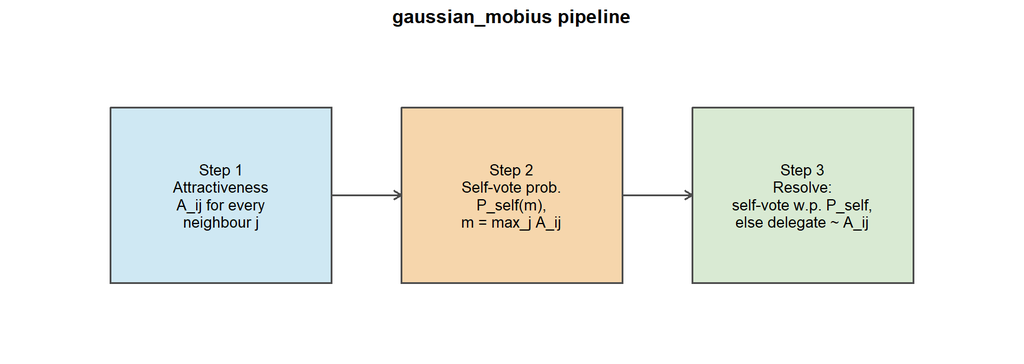

Step 1 computes a full vector of attractivenesses (one per neighbour). Step 2 collapses that vector to a single scalar $m$ (the best neighbour’s attractiveness) and maps it to a self-vote probability. Step 3 draws a Bernoulli($P_{\text{self}}$) coin; on failure, agent $i$ delegates to a neighbour sampled proportional to attractiveness. This is a genuine information bottleneck: **Step 2 never looks at *who* $j^\*$ is (their opinion, their power) – only at *how attractive* they are.** Keep this in mind; it is the single biggest structural difference from the legacy model, discussed at length in Part III.

## 2.2 Step 1: Attractiveness

$$A_{ij} =
2\,\tau_{ij}\,a^{\text{op}}_{ij}\,a^{\text{pw}}_{ij}$$

implemented as `attractiveness_gaussian_log()` in `FunctionVersions.R`. It returns $2\,a^{\text{op}}_{ij}\,a^{\text{pw}}_{ij}$; the trust factor $\tau_{ij}$ is applied afterwards, exactly as for every other attractiveness formula in this codebase (see Part I.5).

### 2.2.1 Opinion factor: a Gaussian kernel

$$a^{\text{op}}_{ij} =
\exp\!\left(-\tfrac{1}{2}\,r_{op}^2\,(o_i - o_j)^2\right)$$

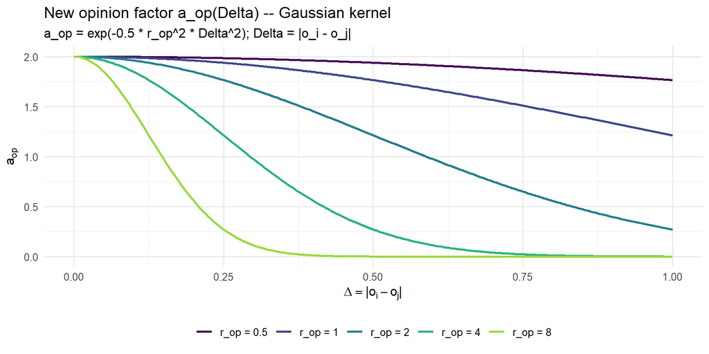

```r
op_dist <- seq(0, 1, length.out = 300)
r_op_vals <- c(0.5, 1, 2, 4, 8)

df_op_new <- expand_grid(delta = op_dist, r_op = r_op_vals) |>
  # attractiveness_gaussian_log(op_i, op_j, pow_i, pow_j, r_op, r_pw): with
  # pow_i = pow_j = 1, a_pw = sig(0) = 0.5 exactly, so dividing the real
  # production function's output by 0.5 recovers a_op(delta) in isolation --
  # this is the ACTUAL sourced function, not a re-derivation.
  mutate(a_op = attractiveness_gaussian_log(0, delta, 1, 1, r_op, 1) / 0.5,
         r_op_label = factor(paste0("r_op = ", r_op), levels = paste0("r_op = ", r_op_vals)))

ggplot(df_op_new, aes(delta, a_op, colour = r_op_label)) +
  geom_line(linewidth = 1) +
  scale_colour_viridis_d(end = 0.85) +
  labs(title = "New opinion factor a_op(Delta) -- Gaussian kernel",
       subtitle = "a_op = exp(-0.5 * r_op^2 * Delta^2); Delta = |o_i - o_j|",
       x = expression(Delta == "|"*o[i]-o[j]*"|"), y = expression(a[op]),
       colour = NULL) +
  theme(legend.position = "bottom")
```

**Numeric example.** At $r_{op}=4$:

```r
tibble(Delta = c(0, 0.1, 0.25, 0.5, 0.75, 1)) |>
  mutate(a_op = attractiveness_gaussian_log(0, Delta, 1, 1, 4, 1) / 0.5) |>
  kable(digits = 4, col.names = c("Opinion distance $\\Delta$", "$a^{\\text{op}}$ (r_op = 4)"))
```

| Opinion distance $\Delta$ | $a^{\text{op}}$ (r_op = 4) |
| --- | --- |
| 0.00 | 2.0000 |
| 0.10 | 1.8462 |
| 0.25 | 1.2131 |
| 0.50 | 0.2707 |
| 0.75 | 0.0222 |
| 1.00 | 0.0007 |

### 2.2.2 Power factor: unchanged from the legacy model

$$a^{\text{pw}}_{ij} =
\sigma\!\left(r_{pw}\,\log\frac{p_j}{p_i}\right), \qquad \sigma(x) =
\frac{1}{1+e^{-x}}$$

This half of the formula is **identical in form** to the legacy model (Part II) – a sigmoid of the log power ratio. It equals $0.5$ when $i$ and $j$ hold equal power, saturates toward $1$ as $j$ becomes arbitrarily more powerful, and toward $0$ as $j$ becomes negligible. $r_{pw}$ is the steepness of that saturation.

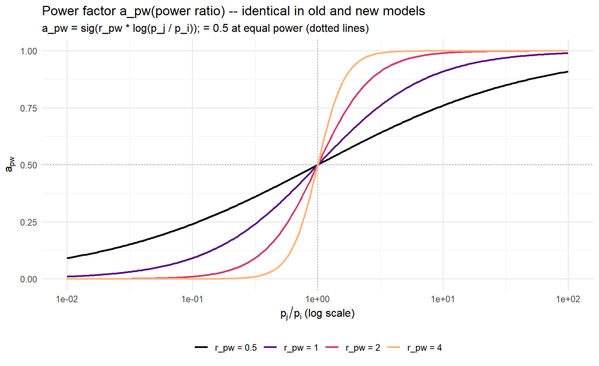

```r
pow_ratio <- 10^seq(-2, 2, length.out = 300)
r_pw_vals <- c(0.5, 1, 2, 4)

df_pw <- expand_grid(ratio = pow_ratio, r_pw = r_pw_vals) |>
  # Delta_op = 0 forces a_op = 1 exactly, so the real function's output /
  # 2 isolates a_pw(ratio). This is the SAME function used for the legacy
  # power factor -- see Part II.2.
  mutate(a_pw = attractiveness_gaussian_log(0, 0, 1, ratio, 1, r_pw) / 2,
         r_pw_label = factor(paste0("r_pw = ", r_pw), levels = paste0("r_pw = ", r_pw_vals)))

ggplot(df_pw, aes(ratio, a_pw, colour = r_pw_label)) +
  geom_line(linewidth = 1) +
  geom_hline(yintercept = 0.5, linetype = "dotted", colour = "grey50") +
  geom_vline(xintercept = 1, linetype = "dotted", colour = "grey50") +
  scale_x_log10() +
  scale_colour_viridis_d(end = 0.85, option = "magma") +
  labs(title = "Power factor a_pw(power ratio) -- identical in old and new models",
       subtitle = "a_pw = sig(r_pw * log(p_j / p_i)); = 0.5 at equal power (dotted lines)",
       x = expression(p[j]/p[i]~"(log scale)"), y = expression(a[pw]), colour = NULL) +
  theme(legend.position = "bottom")
```

```r
tibble(ratio = c(0.1, 0.5, 1, 2, 10)) |>
  mutate(a_pw = attractiveness_gaussian_log(0, 0, 1, ratio, 1, 2) / 2) |>
  kable(digits = 4, col.names = c("Power ratio $p_j/p_i$", "$a^{\\text{pw}}$ (r_pw = 2)"))
```

| Power ratio $p_j/p_i$ | $a^{\text{pw}}$ (r_pw = 2) |
| --- | --- |
| 0.1 | 0.0099 |
| 0.5 | 0.2000 |
| 1.0 | 0.5000 |
| 2.0 | 0.8000 |
| 10.0 | 0.9901 |

## 2.3 Step 2: Self-vote probability – the Mobius curve

Let $m_i = \max_j A_{ij}$ (the attractiveness of $i$’s single best neighbour, on the $[0,2]$ scale established above). The self-vote probability is:

$$P_{\text{self}}(m) = \frac{2 - m}{\,2 +
\dfrac{1-2c}{c}\,m\,}$$

implemented as `p_self_mobius()`. It is a Mobius (rational-linear) transform pinned at three anchors:

| best neighbour | $m$ | $P_{\text{self}}$ | meaning |
| --- | --- | --- | --- |
| nightmare | $0$ | $1$ | always self-vote |
| identical to me | $1$ | $c$ | self-reliance knob |
| perfect | $2$ | $0$ | always delegate |

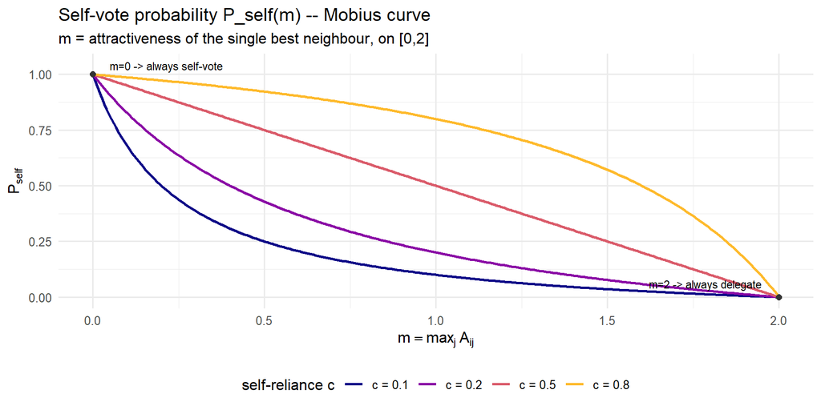

```r
m_grid <- seq(0, 2, length.out = 300)
c_vals <- c(0.1, 0.2, 0.5, 0.8)

df_pself <- expand_grid(m = m_grid, c = c_vals) |>
  mutate(P_self = p_self_mobius(m, c),
         c_label = factor(paste0("c = ", c), levels = paste0("c = ", c_vals)))

ggplot(df_pself, aes(m, P_self, colour = c_label)) +
  geom_line(linewidth = 1) +
  geom_point(data = tibble(m = c(0, 1, 2), P_self = c(1, NA, 0)),
             aes(m, P_self), inherit.aes = FALSE, colour = "grey30", size = 0, alpha = 0) +
  annotate("point", x = 0, y = 1, colour = "grey20", size = 2) +
  annotate("point", x = 2, y = 0, colour = "grey20", size = 2) +
  annotate("text", x = 0.05, y = 1.04, label = "m=0 -> always self-vote", hjust = 0, size = 3) +
  annotate("text", x = 1.95, y = 0.06, label = "m=2 -> always delegate", hjust = 1, size = 3) +
  scale_colour_viridis_d(end = 0.85, option = "plasma") +
  labs(title = "Self-vote probability P_self(m) -- Mobius curve",
       subtitle = "m = attractiveness of the single best neighbour, on [0,2]",
       x = expression(m == max[j]~A[ij]), y = expression(P[self]), colour = "self-reliance c") +
  theme(legend.position = "bottom")
```

**Numeric example.** At $m=1$ (an exactly identical best neighbour), $P_{\text{self}} = c$ *by construction, for every value of $r_{op}$ and $r_{pw}$*:

```r
tibble(c = c(0.1, 0.2, 0.5, 0.8)) |>
  mutate(`P_self(m=1)` = p_self_mobius(1, c)) |>
  kable(digits = 3)
```

| c | P_self(m=1) |
| --- | --- |
| 0.1 | 0.1 |
| 0.2 | 0.2 |
| 0.5 | 0.5 |
| 0.8 | 0.8 |

## 2.4 Step 3: Delegate choice

Conditional on not self-voting, $i$ delegates to a neighbour sampled with probability proportional to $A_{ij}$ among its real (non-padding) neighbours – a straightforward weighted draw, **structurally identical** to the legacy model’s delegate-choice step (`nb[sample.int(length(w), 1L, prob = w)]` in `Network.R`, unchanged by `decision_model`). What differs between the two models is only the *shape* of the weights being sampled from, not the sampling rule itself.

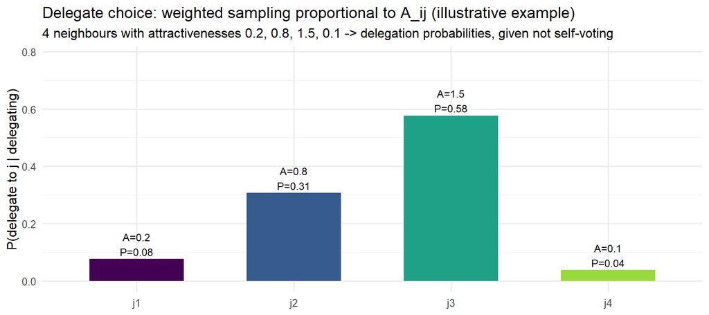

```r
A_vals <- c(j1 = 0.2, j2 = 0.8, j3 = 1.5, j4 = 0.1)
df_choice <- tibble(neighbour = names(A_vals), A = A_vals) |>
  mutate(P_delegate_to = A / sum(A))

ggplot(df_choice, aes(neighbour, P_delegate_to, fill = neighbour)) +
  geom_col(width = 0.6, show.legend = FALSE) +
  geom_text(aes(label = sprintf("A=%.1f\nP=%.2f", A, P_delegate_to)), vjust = -0.15, size = 3.3) +
  scale_fill_viridis_d(end = 0.85) +
  coord_cartesian(ylim = c(0, max(df_choice$P_delegate_to) * 1.35)) +
  labs(title = "Delegate choice: weighted sampling proportional to A_ij (illustrative example)",
       subtitle = "4 neighbours with attractivenesses 0.2, 0.8, 1.5, 0.1 -> delegation probabilities, given not self-voting",
       x = NULL, y = "P(delegate to j | delegating)")
```

## 2.5 Trust interaction (unchanged mechanism, recap only)

Trust is **not** part of the new formula set – it is the existing Report 18 mechanism, applied identically regardless of `decision_model`:

$$\texttt{trust\_mod}_{ij} =
2\,\sigma(\gamma\,\tau_{ij}), \qquad w_{ij} = \texttt{trust\_mod}_{ij}
\times A_{ij}$$

with $\tau_{ij}$ updated each round via the `punish_only` / `reward_punish` rules documented in `Network.R`. `trust_mod = 1` (neutral) when $\gamma=0$ or $\tau_{ij}=0$; it can exceed $1$ (boosting a well-trusted neighbour) or fall toward $0$ (suppressing a mistrusted one).

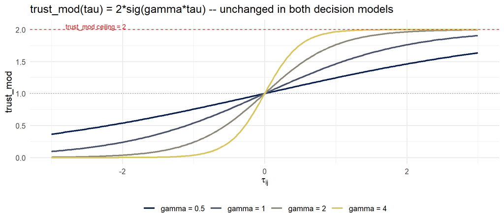

```r
tau_grid <- seq(-3, 3, length.out = 200)
gamma_vals <- c(0.5, 1, 2, 4)

df_trust <- expand_grid(tau = tau_grid, gamma = gamma_vals) |>
  mutate(trust_mod = 2 * .sig(gamma * tau),
         gamma_label = factor(paste0("gamma = ", gamma), levels = paste0("gamma = ", gamma_vals)))

ggplot(df_trust, aes(tau, trust_mod, colour = gamma_label)) +
  geom_line(linewidth = 1) +
  geom_hline(yintercept = 1, linetype = "dotted", colour = "grey50") +
  geom_hline(yintercept = 2, linetype = "dashed", colour = "firebrick3") +
  annotate("text", x = -2.8, y = 2.05, label = "trust_mod ceiling = 2", colour = "firebrick3", size = 3, hjust = 0) +
  scale_colour_viridis_d(end = 0.85, option = "cividis") +
  labs(title = "trust_mod(tau) = 2*sig(gamma*tau) -- unchanged in both decision models",
       x = expression(tau[ij]), y = "trust_mod", colour = NULL) +
  theme(legend.position = "bottom")
```

Note the dashed ceiling at $\texttt{trust\_mod}=2$: this will matter in Part III.6, because the new model’s $m$ is computed from the *trust-adjusted* weight $w_{j^\*}$, not the raw attractiveness.

## 2.6 Parameter glossary (new model)

```r
tibble(
  Parameter = c("r_op", "r_pw", "self_reliance_c", "gamma", "lambda", "trust_mode"),
  Controls = c(
    "Inverse width of the Gaussian opinion kernel a_op. Larger = narrower = more opinion-selective.",
    "Steepness of the power-ratio sigmoid a_pw. Larger = more power-deferential.",
    "Self-reliance knob c in the Mobius P_self curve. Larger = more self-reliant (delegates only to clearly-better neighbours). Independent of r_op/r_pw.",
    "Trust sensitivity: how strongly accumulated trust tau rescales attractiveness (unchanged mechanism).",
    "Trust decay/momentum: how much of last round's tau carries over (unchanged mechanism).",
    "'punish_only' or 'reward_punish' trust update rule (unchanged mechanism)."
  ),
  `Typical range` = c("0.5 - 8", "0.5 - 8", "0.1 - 0.9 (open interval)", "0 (off) - 8", "0 - 1", "categorical")
) |>
  kable()
```

| Parameter | Controls | Typical range |
| --- | --- | --- |
| r_op | Inverse width of the Gaussian opinion kernel a_op. Larger = narrower = more opinion-selective. | 0.5 - 8 |
| r_pw | Steepness of the power-ratio sigmoid a_pw. Larger = more power-deferential. | 0.5 - 8 |
| self_reliance_c | Self-reliance knob c in the Mobius P_self curve. Larger = more self-reliant (delegates only to clearly-better neighbours). Independent of r_op/r_pw. | 0.1 - 0.9 (open interval) |
| gamma | Trust sensitivity: how strongly accumulated trust tau rescales attractiveness (unchanged mechanism). | 0 (off) - 8 |
| lambda | Trust decay/momentum: how much of last round’s tau carries over (unchanged mechanism). | 0 - 1 |
| trust_mode | ‘punish_only’ or ‘reward_punish’ trust update rule (unchanged mechanism). | categorical |

# 3 Part II – Recap: The Legacy Dual-Sigmoid Model

Reports 15-19 use `decision_model = "legacy"` (the default), summarised here for direct comparison.

## 3.1 Attractiveness (dual sigmoid)

$$A_{ij} =
\sigma\big(r_{op}(1-2|o_i-o_j|)\big)\,\times\,\sigma\!\left(r_{pw}\log\frac{p_j}{p_i}\right)$$

implemented as `attractiveness_dual_sigmoid()`. Both factors are sigmoids: opinion similarity $1-2|o_i-o_j|$ is remapped from $[-1,1]$ (identical to maximally distant) through a sigmoid, and the power factor is the same log-ratio sigmoid used in the new model.

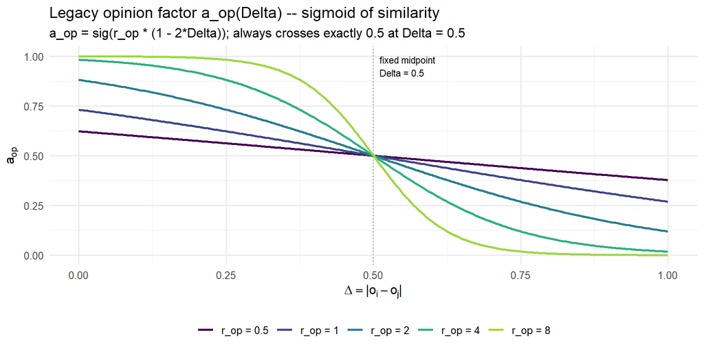

```r
df_op_old <- expand_grid(delta = op_dist, r_op = r_op_vals) |>
  mutate(a_op = attractiveness_dual_sigmoid(0, delta, 1, 1, r_op, 1) / 0.5,
         r_op_label = factor(paste0("r_op = ", r_op), levels = paste0("r_op = ", r_op_vals)))

ggplot(df_op_old, aes(delta, a_op, colour = r_op_label)) +
  geom_line(linewidth = 1) +
  geom_vline(xintercept = 0.5, linetype = "dotted", colour = "grey50") +
  annotate("text", x = 0.51, y = 0.95, label = "fixed midpoint\nDelta = 0.5", hjust = 0, size = 3) +
  scale_colour_viridis_d(end = 0.85) +
  labs(title = "Legacy opinion factor a_op(Delta) -- sigmoid of similarity",
       subtitle = "a_op = sig(r_op * (1 - 2*Delta)); always crosses exactly 0.5 at Delta = 0.5",
       x = expression(Delta == "|"*o[i]-o[j]*"|"), y = expression(a[op]), colour = NULL) +
  theme(legend.position = "bottom")
```

The power factor $a^{\text{pw}}$ is the **identical function** already plotted in Part I.2 – the legacy and new models do not differ on the power dimension at all.

## 3.2 Self-weight (dual-sigmoid argmax) and the “confidence” patch

Given $j^\*=\arg\max_j A_{ij}$ (found using the same attractiveness weights as Step 3), the legacy self-weight is a **second, independent** formula that re-derives a weight from $j^\*$’s specific opinion and power gap – it does *not* reuse $A_{ij^\*}$ directly:

$$w^{\text{raw}}_{\text{self}} =
\sigma\big(r_{op}(2|o_i-o_{j^\*}|-1)\big) \times
\sigma\!\left(r_{pw}\log\frac{p_i}{p_{j^\*}}\right)$$

This is a mirror image of the attractiveness formula (opinion sign flipped: far away $\Rightarrow$ high self-confidence). `self_weight_mode` controls what happens next:

- `"raw"`: use $w^{\text{raw}}_{\text{self}}$ as-is.
- `"confidence"` (used in Reports 17-19): blend it toward “always self-vote” using a saturating function of total responsiveness $r_{\text{tot}} = r_{op}+r_{pw}+r_{ingroup}$ (or their mean, per `confidence_agg`):

$$\text{conf} =
\frac{r_{\text{tot}}}{1+r_{\text{tot}}}, \qquad
w_{\text{self}} = (1-\text{conf}) + \text{conf}\cdot
w^{\text{raw}}_{\text{self}}$$

This blending step exists to fix a specific, documented artefact: at $r_{op}=r_{pw}=0$ (no responsiveness at all), $w^{\text{raw}}_{\text{self}} = \sigma(0)\cdot\sigma(0) = 0.25$ exactly – a **floor** that keeps roughly a quarter of agents self-voting even when nobody cares about opinion or power at all, which is not a meaningful behavioural claim, just an artefact of multiplying two sigmoids evaluated at zero. `"confidence"` mode papers over this by interpolating toward $1$ (self-vote) as responsiveness $\to 0$.

```r
tibble(r = c(0, 0.5, 1, 2, 4, 8)) |>
  mutate(
    `w_self_raw (identical j*)` = .sig(r * (2 * 0 - 1)) * .sig(r * log(1)),
    `confidence blend (r_ingroup=0)` = {
      conf <- (2 * r) / (1 + 2 * r)  # r_tot = r_op + r_pw = 2r here
      (1 - conf) + conf * `w_self_raw (identical j*)`
    }
  ) |>
  kable(digits = 4)
```

| r | w_self_raw (identical j*) | confidence blend (r_ingroup=0) |
| --- | --- | --- |
| 0.0 | 0.2500 | 1.0000 |
| 0.5 | 0.1888 | 0.5944 |
| 1.0 | 0.1345 | 0.4230 |
| 2.0 | 0.0596 | 0.2477 |
| 4.0 | 0.0090 | 0.1191 |
| 8.0 | 0.0002 | 0.0590 |

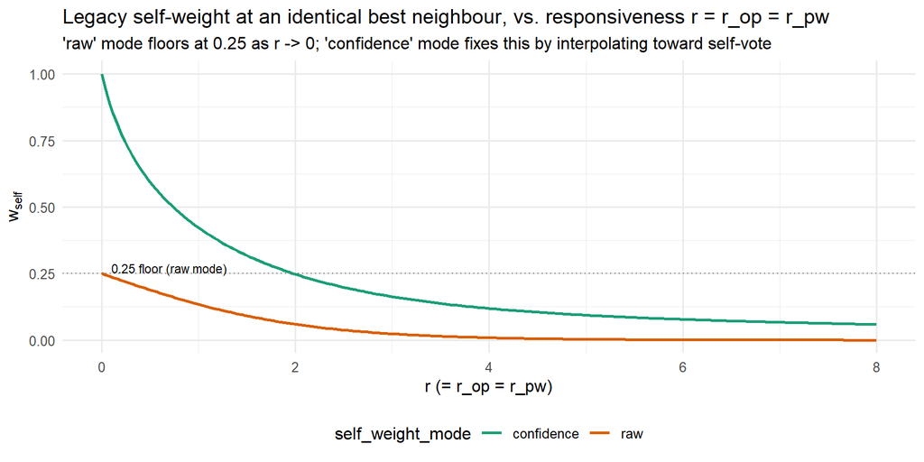

```r
r_seq <- seq(0, 8, length.out = 200)
df_conf <- tibble(r = r_seq) |>
  mutate(
    w_raw = .sig(r * (2 * 0 - 1)) * .sig(r * log(1)),
    conf  = (2 * r) / (1 + 2 * r),
    w_confidence = (1 - conf) + conf * w_raw
  ) |>
  pivot_longer(c(w_raw, w_confidence), names_to = "mode", values_to = "w_self") |>
  mutate(mode = recode(mode, w_raw = "raw", w_confidence = "confidence"))

ggplot(df_conf, aes(r, w_self, colour = mode)) +
  geom_line(linewidth = 1) +
  geom_hline(yintercept = 0.25, linetype = "dotted", colour = "grey50") +
  annotate("text", x = 0.1, y = 0.27, label = "0.25 floor (raw mode)", size = 3, hjust = 0) +
  scale_colour_manual(values = c(raw = "#d95f02", confidence = "#1b9e77")) +
  labs(title = "Legacy self-weight at an identical best neighbour, vs. responsiveness r = r_op = r_pw",
       subtitle = "'raw' mode floors at 0.25 as r -> 0; 'confidence' mode fixes this by interpolating toward self-vote",
       x = "r (= r_op = r_pw)", y = expression(w[self]), colour = "self_weight_mode") +
  theme(legend.position = "bottom")
```

## 3.3 Delegate choice

Identical mechanism to Part I.4 – weighted sampling proportional to $A_{ij}$, unaffected by `decision_model`.

## 3.4 Parameter glossary (legacy model)

```r
tibble(
  Parameter = c("r_op", "r_pw", "self_weight_mode", "confidence_agg", "r_ingroup", "gamma / lambda / trust_mode"),
  Controls = c(
    "Steepness of the opinion-similarity sigmoid AND (via the mirrored formula) part of self-confidence.",
    "Steepness of the power-ratio sigmoid AND (via the mirrored formula) part of self-confidence.",
    "'raw' (use w_self_raw as-is) or 'confidence' (blend toward always-self-vote at low responsiveness).",
    "'sum' or 'mean' -- how r_op/r_pw/r_ingroup combine into r_tot for the confidence blend.",
    "Ingroup responsiveness -- multiplies attractiveness by sig(+-r_ingroup), also feeds r_tot.",
    "Same trust mechanism as the new model, unaffected by decision_model."
  )
) |>
  kable()
```

| Parameter | Controls |
| --- | --- |
| r_op | Steepness of the opinion-similarity sigmoid AND (via the mirrored formula) part of self-confidence. |
| r_pw | Steepness of the power-ratio sigmoid AND (via the mirrored formula) part of self-confidence. |
| self_weight_mode | ‘raw’ (use w_self_raw as-is) or ‘confidence’ (blend toward always-self-vote at low responsiveness). |
| confidence_agg | ‘sum’ or ‘mean’ – how r_op/r_pw/r_ingroup combine into r_tot for the confidence blend. |
| r_ingroup | Ingroup responsiveness – multiplies attractiveness by sig(+-r_ingroup), also feeds r_tot. |
| gamma / lambda / trust_mode | Same trust mechanism as the new model, unaffected by decision_model. |

# 4 Part III – Detailed Comparison

## 4.1 III.1 What changed, in one table

```r
tibble(
  Component = c("Opinion factor", "Power factor", "Self-vote step",
                "Self-vote inputs", "Delegate choice", "Trust interaction"),
  Legacy = c(
    "$\\sigma(r_{op}(1-2\\Delta))$ -- sigmoid, fixed midpoint at $\\Delta=0.5$",
    "$\\sigma(r_{pw}\\log(p_j/p_i))$",
    "Re-derived formula, mirror of attractiveness, evaluated at $j^*$'s raw $(o_{j^*}, p_{j^*})$",
    "2 numbers: $\\Delta(i,j^*)$ and power ratio $(i,j^*)$, both fed through $r_{op}, r_{pw}$ again",
    "Sample $\\propto A_{ij}$ among neighbours",
    "trust_mod multiplies $A_{ij}$ (affects $j^*$ selection and sampling only)"
  ),
  `Gaussian/Mobius` = c(
    "$\\exp(-\\tfrac12 r_{op}^2\\Delta^2)$ -- Gaussian, $r_{op}$-dependent half-width",
    "$\\sigma(r_{pw}\\log(p_j/p_i))$ -- unchanged",
    "$P_{\\text{self}}(m)$, Mobius curve, single free parameter $c$",
    "1 number: $m = A_{ij^*}$ (already includes trust/ingroup)",
    "Sample $\\propto A_{ij}$ among neighbours -- unchanged",
    "trust_mod multiplies $A_{ij}$, feeding directly into $m$ (see III.6)"
  )
) |>
  kable(escape = FALSE)
```

| Component | Legacy | Gaussian/Mobius |
| --- | --- | --- |
| Opinion factor | $\sigma(r_{op}(1-2\Delta))$ – sigmoid, fixed midpoint at $\Delta=0.5$ | $\exp(-\tfrac12 r_{op}^2\Delta^2)$ – Gaussian, $r_{op}$-dependent half-width |
| Power factor | $\sigma(r_{pw}\log(p_j/p_i))$ | $\sigma(r_{pw}\log(p_j/p_i))$ – unchanged |
| Self-vote step | Re-derived formula, mirror of attractiveness, evaluated at $j^*$’s raw $(o_{j^*}, p_{j^*})$ | $P_{\text{self}}(m)$, Mobius curve, single free parameter $c$ |
| Self-vote inputs | 2 numbers: $\Delta(i,j^*)$ and power ratio $(i,j^*)$, both fed through $r_{op}, r_{pw}$ again | 1 number: $m = A_{ij^*}$ (already includes trust/ingroup) |
| Delegate choice | Sample $\propto A_{ij}$ among neighbours | Sample $\propto A_{ij}$ among neighbours – unchanged |
| Trust interaction | trust_mod multiplies $A_{ij}$ (affects $j^*$ selection and sampling only) | trust_mod multiplies $A_{ij}$, feeding directly into $m$ (see III.6) |

The power factor and the delegate-choice mechanism are **literally the same code** in both models. Everything else changed. The next five subsections unpack why each change matters.

## 4.2 III.2 Ceiling non-equivalence: what does “identical neighbour” mean?

An *identical* neighbour ($\Delta=0$, equal power) is the natural reference point for “as attractive as it gets, ideologically.” The two models treat it very differently:

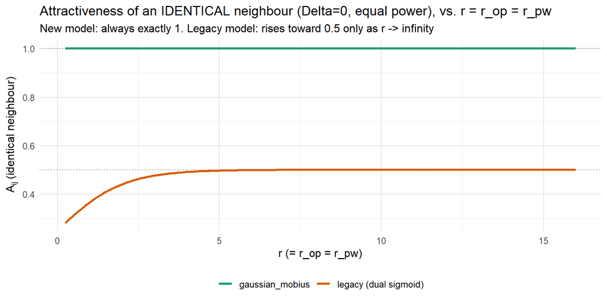

```r
r_seq2 <- seq(0.25, 16, length.out = 200)
df_ceiling <- tibble(r = r_seq2) |>
  mutate(
    old = attractiveness_dual_sigmoid(0, 0, 1, 1, r, r),
    new = attractiveness_gaussian_log(0, 0, 1, 1, r, r)
  ) |>
  pivot_longer(c(old, new), names_to = "model", values_to = "A_identical")

ggplot(df_ceiling, aes(r, A_identical, colour = model)) +
  geom_line(linewidth = 1.1) +
  geom_hline(yintercept = c(0.5, 1), linetype = "dotted", colour = "grey50") +
  scale_colour_manual(values = c(old = "#d95f02", new = "#1b9e77"),
                       labels = c(old = "legacy (dual sigmoid)", new = "gaussian_mobius")) +
  labs(title = "Attractiveness of an IDENTICAL neighbour (Delta=0, equal power), vs. r = r_op = r_pw",
       subtitle = "New model: always exactly 1. Legacy model: rises toward 0.5 only as r -> infinity",
       x = "r (= r_op = r_pw)", y = expression(A[ij]~"(identical neighbour)"), colour = NULL) +
  theme(legend.position = "bottom")
```

At $r=4$ (a typical “responsive” setting used throughout Reports 17-19), an identical neighbour scores $A \approx$ 0.491 under the legacy model but exactly $1$ under the new one. **The new model’s “1” is an invariant reference point, independent of $r_{op}, r_{pw}$; the legacy model’s ceiling is itself a function of responsiveness, and never actually reaches even $0.5$ at finite $r$.** This is a direct, mechanical consequence of multiplying two sigmoids that individually saturate below 1 rather than a Gaussian that reaches exactly 1 at zero distance.

## 4.3 III.3 Decoupling: is self-reliance its own parameter, or entangled with $r$?

This is the most consequential conceptual change. Evaluate each model’s self-vote quantity specifically at the “identical best neighbour” case ($m=1$ for the new model; $\Delta=0$, ratio$=1$ for the legacy formula):

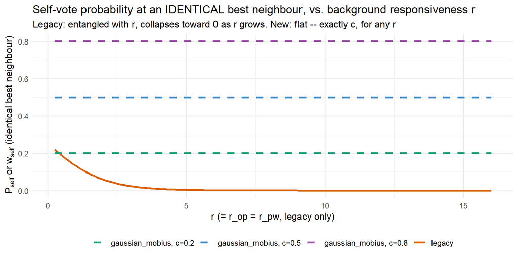

```r
df_decouple_old <- tibble(r = r_seq2) |>
  mutate(w_self = .sig(r * (2 * 0 - 1)) * .sig(r * log(1)), model = "legacy")

df_decouple_new <- expand_grid(r = r_seq2, c = c(0.2, 0.5, 0.8)) |>
  mutate(w_self = p_self_mobius(1, c), model = paste0("gaussian_mobius, c=", c))

ggplot() +
  geom_line(data = df_decouple_old, aes(r, w_self, colour = model), linewidth = 1.1) +
  geom_line(data = df_decouple_new, aes(r, w_self, colour = model), linewidth = 1.1, linetype = "dashed") +
  scale_colour_manual(values = c("legacy" = "#d95f02",
                                 "gaussian_mobius, c=0.2" = "#1b9e77",
                                 "gaussian_mobius, c=0.5" = "#377eb8",
                                 "gaussian_mobius, c=0.8" = "#984ea3")) +
  labs(title = "Self-vote probability at an IDENTICAL best neighbour, vs. background responsiveness r",
       subtitle = "Legacy: entangled with r, collapses toward 0 as r grows. New: flat -- exactly c, for any r",
       x = "r (= r_op = r_pw, legacy only)", y = expression(P[self]~"or"~w[self]~"(identical best neighbour)"),
       colour = NULL) +
  theme(legend.position = "bottom")
```

Under the legacy model, self-reliance when facing an identical neighbour is not a free choice – it is *whatever falls out* of $r_{op}, r_{pw}$, which also simultaneously control how sharply opinion/power gate attractiveness. Turning up “how much do I care about opinion similarity” (raising $r_{op}$) **automatically and inescapably** turns down “how likely am I to still vote for myself when facing someone just like me” (from $0.25$ at $r=0$ down to essentially $0$ by $r\approx8$, confirmed numerically above). There is no way, in the legacy model, to have a highly opinion-selective agent who is *also* strongly self-reliant, short of the `"confidence"` patch, which addresses only the $r\to0$ floor, not this coupling.

The new model removes this coupling entirely: $c$ is set independently and $P_{\text{self}}(m{=}1)=c$ for *every* $r_{op}$. An agent can be extremely opinion-selective ($r_{op}=8$) and still self-reliant ($c=0.8$) simultaneously – a combination that is difficult to reach in the legacy model and impossible to reach *exactly* by construction.

## 4.4 III.4 Where does $r_{op}$ actually act? A hidden non-equivalence

Both models expose an argument literally called `r_op`, swept over the same values in Report 20 as in Report 19 ($1, 4, 8$). **These are not comparable in the same units.** Consider the opinion distance at which $a^{\text{op}}=0.5$ (the “half-attractiveness point”):

- **Legacy:** $\sigma(r_{op}(1-2\Delta))=0.5 \iff \Delta = 0.5$, **for every value of $r_{op}$.** $r_{op}$ only controls how *sharply* the curve transitions around that fixed midpoint – it never moves.
- **New:** $\exp(-\tfrac12 r_{op}^2\Delta^2)=0.5 \iff \Delta = \sqrt{2\ln2}/r_{op} \approx 1.1774/r_{op}$ – the half-attractiveness point *moves inward* as $r_{op}$ grows.

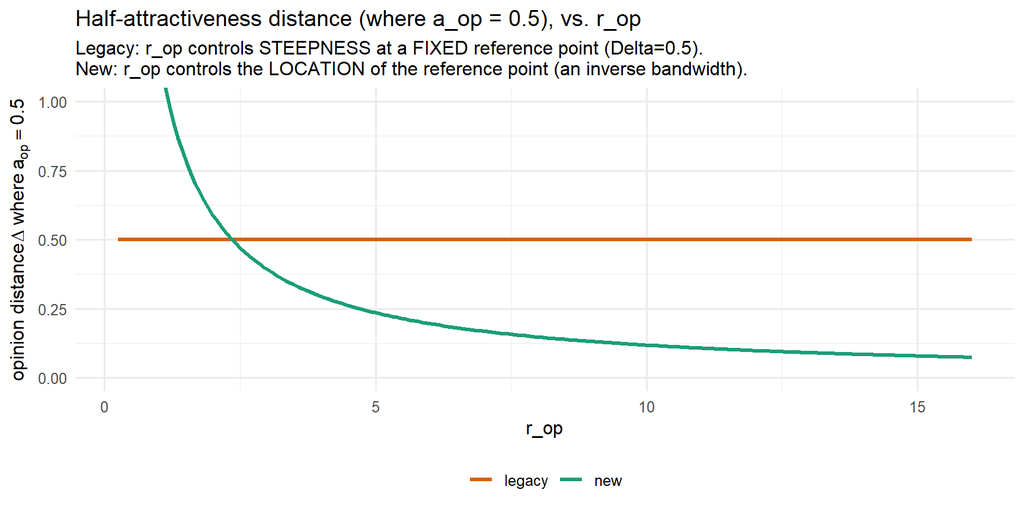

```r
r_seq3 <- seq(0.25, 16, length.out = 200)
df_half <- tibble(r = r_seq3) |>
  mutate(legacy = 0.5, new = sqrt(2 * log(2)) / r) |>
  pivot_longer(c(legacy, new), names_to = "model", values_to = "half_distance")

ggplot(df_half, aes(r, half_distance, colour = model)) +
  geom_line(linewidth = 1.1) +
  scale_colour_manual(values = c(legacy = "#d95f02", new = "#1b9e77")) +
  coord_cartesian(ylim = c(0, 1)) +
  labs(title = "Half-attractiveness distance (where a_op = 0.5), vs. r_op",
       subtitle = "Legacy: r_op controls STEEPNESS at a FIXED reference point (Delta=0.5).\nNew: r_op controls the LOCATION of the reference point (an inverse bandwidth).",
       x = "r_op", y = expression("opinion distance"~Delta~"where"~a[op]==0.5), colour = NULL) +
  theme(legend.position = "bottom")
```

**Practical consequence:** “$r_{op}=8$” means “a sharp step exactly at $\Delta=0.5$” in the legacy model, but “a narrow bump that has already collapsed by $\Delta\approx0.15$” in the new model. Report 20 sweeps the same numeric values as Report 19 for continuity, but any claim of the form “the effect of $r_{op}$ is X in both models” should be read as label-comparable, not magnitude-comparable, unless the sweep is re-calibrated via the mapping above (see Part VII.3 for a concrete fix).

## 4.5 III.5 Sharper echo chambers?

Because the new model’s opinion gate is genuinely bounded away from the legacy sigmoid’s shallow tails (a Gaussian’s tail decays like $e^{-\Delta^2}$, faster than a sigmoid’s like $e^{-\Delta}$ for large arguments), a highly polarised, highly opinion-responsive population is expected to show attractiveness collapsing *faster* across an opinion gap under `gaussian_mobius` than under `legacy`, at matched nominal $r_{op}$. Combined with III.4 (the new model’s bandwidth also *shrinks* with $r_{op}$, compounding the effect), this predicts: **more baseline opinion-driven self-segregation under the new model, before ingroup preference ($r_{ingroup}$) is even switched on.** This is directly relevant to Report 20’s hypotheses – see Part V.

## 4.6 III.6 A genuine edge case: trust can push $m$ past its designed ceiling

Recall from Part I.5 that $\texttt{trust\_mod} = 2\sigma(\gamma\tau)$ can itself range up to (not including) $2$. In the **legacy** model, trust only ever affects (a) *which* neighbour becomes $j^\*$ (the argmax is computed over trust-adjusted weights) and (b) the delegate-choice sampling weights. The self-weight formula in Step 2 is *recomputed from scratch* from $j^\*$’s raw opinion/power gap – it never sees the trust-adjusted number itself, so it is mathematically guaranteed to stay in $[0,1]$ (a product of two sigmoids) regardless of how extreme trust becomes.

The **new** model’s Step 2 uses $m = w_{j^\*}$ directly – the *trust-adjusted* attractiveness. If trust pushes a neighbour’s weight above the formula’s designed ceiling of $2$ (entirely possible: $A_{ij}\le2$ times $\texttt{trust\_mod}<2$ can exceed $2$), the Mobius formula extrapolates outside its intended domain:

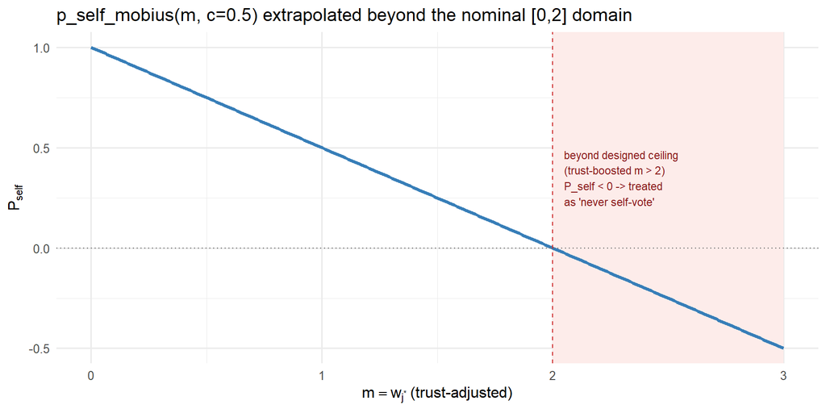

```r
m_ext <- seq(0, 3, length.out = 300)
df_edge <- tibble(m = m_ext) |> mutate(P_self = p_self_mobius(m, 0.5))

ggplot(df_edge, aes(m, P_self)) +
  geom_rect(aes(xmin = 2, xmax = 3, ymin = -Inf, ymax = Inf), fill = "#fdecea", alpha = 0.6, inherit.aes = FALSE) +
  geom_line(linewidth = 1.1, colour = "#377eb8") +
  geom_hline(yintercept = 0, linetype = "dotted", colour = "grey40") +
  geom_vline(xintercept = 2, linetype = "dashed", colour = "firebrick3") +
  annotate("text", x = 2.05, y = 0.35, label = "beyond designed ceiling\n(trust-boosted m > 2)\nP_self < 0 -> treated\nas 'never self-vote'",
           hjust = 0, size = 3, colour = "firebrick4") +
  labs(title = "p_self_mobius(m, c=0.5) extrapolated beyond the nominal [0,2] domain",
       x = expression(m == w[j^"*"]~"(trust-adjusted)"), y = expression(P[self]))
```

```r
tibble(m = c(0, 1, 1.5, 2, 2.5, 3)) |>
  mutate(P_self = p_self_mobius(m, 0.5)) |>
  kable(digits = 4, caption = "P_self(m, c=0.5): note the sign flip past m=2")
```

P_self(m, c=0.5): note the sign flip past m=2

| m | P_self |
| --- | --- |
| 0.0 | 1.00 |
| 1.0 | 0.50 |
| 1.5 | 0.25 |
| 2.0 | 0.00 |
| 2.5 | -0.25 |
| 3.0 | -0.50 |

Negative $P_{\text{self}}$ is not a crash – `runif(1) < P_self` is simply always `FALSE` for a negative threshold, so the practical effect is “always delegate,” which is arguably the *intended direction* (a strongly-trust-boosted neighbour should be very delegate-worthy) but is reached through an out-of-domain formula evaluation rather than by design. This is flagged explicitly as a concrete, fixable weakness in Part VII.

# 5 Part IV – Advantages and Disadvantages

```r
tibble(
  Criterion = c("Realism", "Interpretability", "Flexibility", "Robustness",
                "Computational complexity", "Ease of parameter tuning"),
  `Legacy (dual sigmoid)` = c(
    "Sigmoid saturation is a common choice-model primitive (logistic response); opinion cutoff shape is arguably less 'natural' than a bell curve of similarity.",
    "Single family of parameters (r_op, r_pw, r_ingroup) drives everything, but the self-weight formula's meaning is only clear once you see it's a 'mirror' of attractiveness -- non-obvious on first read.",
    "self_weight_mode/confidence_agg add two more categorical switches on top of r_op/r_pw to reach a full delegation-rate range -- flexible, but via a layered patch rather than a single mechanism.",
    "Self-weight is always a valid probability in [0,1] by construction, regardless of how extreme trust or attractiveness become -- no known domain violations.",
    "One extra sigmoid evaluation per agent per round vs. the new model -- negligible difference either way.",
    "r_op/r_pw jointly govern opinion gating AND self-reliance -- tuning one for a target delegation rate can silently distort the other."
  ),
  `Gaussian/Mobius` = c(
    "Gaussian opinion kernel matches a natural 'similarity as closeness in a metric space' intuition; Mobius curve is a clean, purpose-built interpolant with named anchors rather than an emergent by-product of two sigmoids.",
    "Anchors (m=0->1, m=1->c, m=2->0) are directly readable off the formula; c has a literal meaning ('self-vote probability when facing an identical neighbour') independent of anything else.",
    "c is a single, dedicated self-reliance knob -- can be swept independently of r_op/r_pw without any patch or blending logic.",
    "m can exceed the formula's designed [0,2] ceiling under strong reward+punish trust, producing negative (out-of-domain) probabilities -- see III.6. Rare, but real and currently unguarded.",
    "Same order of cost (one exp(), one division) -- negligible difference either way.",
    "c alone controls self-reliance; r_op/r_pw only shape the opinion/power kernels -- but r_op's meaning is not comparable across models (III.4), complicating any joint calibration against legacy results."
  )
) |>
  kable(escape = FALSE)
```

[output not shown]

**When legacy may still be preferable.** If the research question is specifically about the interaction between *responsiveness* and *self-reliance being the same underlying quantity* (e.g. modelling agents whose confidence and pickiness are genuinely the same trait), the legacy formula’s entanglement is a feature, not a bug. It is also the already-published, already-validated basis for Reports 15-19; switching wholesale would break continuity with that body of results unless `decision_model = "legacy"` is retained for replication (which it is).

# 6 Part V – Impact on the Simulation

## 6.1 What we expect to change

- **Cross-group delegation baseline (H1c/H2c, Report 20).** Per III.5, the Gaussian kernel plus its shrinking bandwidth should produce *lower baseline cross-group attractiveness* under polarisation, independent of $r_{ingroup}$. If Report 20 finds a *smaller marginal effect* of $r_{ingroup}$ on cross-group delegation than Report 19 did, that is not necessarily evidence against H1c/H2c – it may simply mean the opinion kernel is already doing part of that work, leaving less room for $r_{ingroup}$ to add on top. This is a genuine confound to check before interpreting effect sizes across the two reports.
- **Delegation rate range.** The `"confidence"` patch was built specifically to let legacy delegation rates span the full $[0,1]$ range; the Mobius curve does this natively via $c$. We do not expect a qualitative difference in *achievable* delegation rates, but the *shape* of how delegation rate responds to $r_{op}$ should differ, because $r_{op}$ now also reshapes the opinion kernel’s bandwidth (III.4), not just its steepness at a fixed point.
- **Voting power concentration (Gini, top-5% share).** Indirectly affected through the delegation-rate and chain-length channels above – no direct mechanical change, since `compute_power()` itself is untouched.
- **Trust dynamics.** The trust *update* rule is identical, but its *consequence* differs: under legacy, trust cannot destabilise the self-weight formula (III.6); under the new model, strong reward+punish trust interacts with the Mobius ceiling. Expect this to matter mainly in Report 18/20-style trust-heavy diagnostic sweeps (high $\gamma$, high $\lambda$), not in the baseline Report 20 grid where $\gamma=r_{background} \le 8$ and $\lambda=0.5$.
- **Stability / convergence.** No structural reason to expect a change: both models resolve the delegation decision independently each round from the current opinion/power/trust state; neither introduces new path-dependence.

## 6.2 Small-scale sensitivity check (this document’s own simulation)

To make the discussion above concrete rather than purely formulaic, this section runs a small, self-contained sweep with the *actual* simulation code (not a toy re-derivation) – deliberately with **no group structure** (uniform-random opinions, no minority split), so that only the decision-model effect is visible, uncontaminated by Report 20’s separate ingroup-preference analysis.

```r
sens_seeds <- 1:3
r_vals     <- c(0.5, 1, 2, 4, 8)

run_sens <- function(seed, r, model) {
  res <- simulate_liquid_democracy(
    seed = seed, n_per_community = 120, n_communities = 1, node_degree = 6,
    T = 12, r_op = r, r_pw = r, p_rewire = 0.05,
    decision_model = model,
    self_reliance_c = 0.5,       # ignored when model == "legacy"
    self_weight_mode = "confidence",  # ignored when model == "gaussian_mobius"
    gamma = r, lambda = 0.5, trust_mode = "reward_punish",
    sigma_opinion = "auto"
  )
  snaps <- res$snapshots |> dplyr::filter(round >= 12 - 4)
  tibble(seed = seed, r = r, model = model,
         delegation_rate  = mean(snaps$delegation_rate, na.rm = TRUE),
         avg_drift        = mean(snaps$avg_drift, na.rm = TRUE),
         gini_power       = mean(snaps$gini_power, na.rm = TRUE),
         top5_power_share = mean(snaps$top5_power_share, na.rm = TRUE))
}

grid_sens <- expand_grid(seed = sens_seeds, r = r_vals, model = c("legacy", "gaussian_mobius"))
sens_raw  <- pmap_dfr(grid_sens, run_sens)

sens_agg <- sens_raw |>
  group_by(r, model) |>
  summarise(across(c(delegation_rate, avg_drift, gini_power, top5_power_share), mean), .groups = "drop")
```

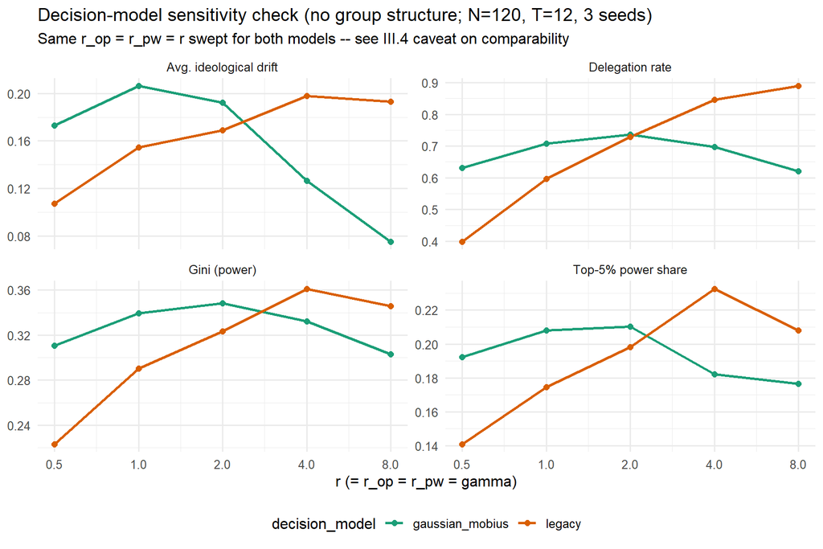

```r
sens_long <- sens_agg |>
  pivot_longer(c(delegation_rate, avg_drift, gini_power, top5_power_share),
               names_to = "metric", values_to = "value") |>
  mutate(metric = recode(metric,
                         delegation_rate = "Delegation rate", avg_drift = "Avg. ideological drift",
                         gini_power = "Gini (power)", top5_power_share = "Top-5% power share"))

ggplot(sens_long, aes(r, value, colour = model)) +
  geom_line(linewidth = 1) + geom_point(size = 2) +
  facet_wrap(~ metric, scales = "free_y") +
  scale_colour_manual(values = c(legacy = "#d95f02", gaussian_mobius = "#1b9e77")) +
  scale_x_log10(breaks = r_vals) +
  labs(title = "Decision-model sensitivity check (no group structure; N=120, T=12, 3 seeds)",
       subtitle = "Same r_op = r_pw = r swept for both models -- see III.4 caveat on comparability",
       x = "r (= r_op = r_pw = gamma)", y = NULL, colour = "decision_model") +
  theme(legend.position = "bottom")
```

## 6.3 The new model’s independent self-reliance axis

This is the sensitivity surface that **cannot be produced by the legacy model at all** without conflating it with $r_{op}/r_{pw}$ (III.3) – a direct visualisation of what the new parameter buys:

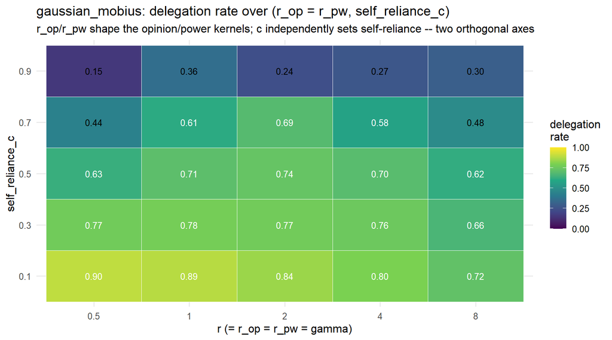

```r
c_vals_heat <- c(0.1, 0.3, 0.5, 0.7, 0.9)

run_heat <- function(seed, r, c_self) {
  res <- simulate_liquid_democracy(
    seed = seed, n_per_community = 120, n_communities = 1, node_degree = 6,
    T = 12, r_op = r, r_pw = r, p_rewire = 0.05,
    decision_model = "gaussian_mobius", self_reliance_c = c_self,
    gamma = r, lambda = 0.5, trust_mode = "reward_punish",
    sigma_opinion = "auto"
  )
  snaps <- res$snapshots |> dplyr::filter(round >= 12 - 4)
  tibble(seed = seed, r = r, c_self = c_self,
         delegation_rate = mean(snaps$delegation_rate, na.rm = TRUE))
}

grid_heat <- expand_grid(seed = sens_seeds, r = r_vals, c_self = c_vals_heat)
heat_raw  <- pmap_dfr(grid_heat, run_heat)

heat_agg <- heat_raw |> group_by(r, c_self) |> summarise(delegation_rate = mean(delegation_rate), .groups = "drop")

ggplot(heat_agg, aes(factor(r), factor(c_self), fill = delegation_rate)) +
  geom_tile(colour = "white") +
  geom_text(aes(label = sprintf("%.2f", delegation_rate)), size = 3.4,
            colour = ifelse(heat_agg$delegation_rate > 0.5, "white", "black")) +
  scale_fill_viridis_c(limits = c(0, 1), option = "viridis") +
  labs(title = "gaussian_mobius: delegation rate over (r_op = r_pw, self_reliance_c)",
       subtitle = "r_op/r_pw shape the opinion/power kernels; c independently sets self-reliance -- two orthogonal axes",
       x = "r (= r_op = r_pw = gamma)", y = "self_reliance_c", fill = "delegation\nrate")
```

# 7 Part VI – Consolidated Visual Comparison

## 7.1 Side-by-side decision flow

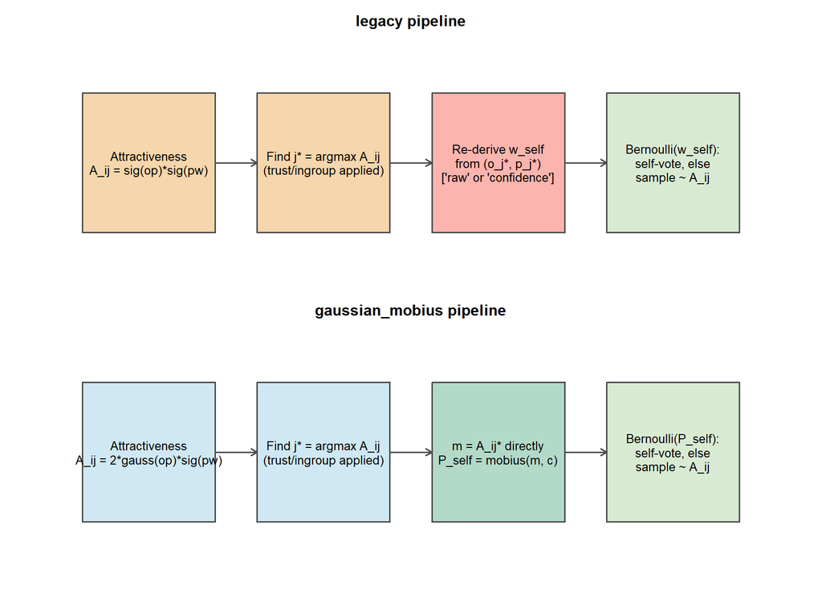

The structural difference is entirely in the third box: **legacy re-derives** a fresh quantity from $j^\*$’s identity; **the new model reuses** the number already computed in box 1/2. This single design choice is the source of both the model’s main advantage (decoupled, clean self-reliance parameter, III.3) and its main new risk (out-of-domain $m$, III.6).

## 7.2 Combined kernel comparison (opinion + power, both models)

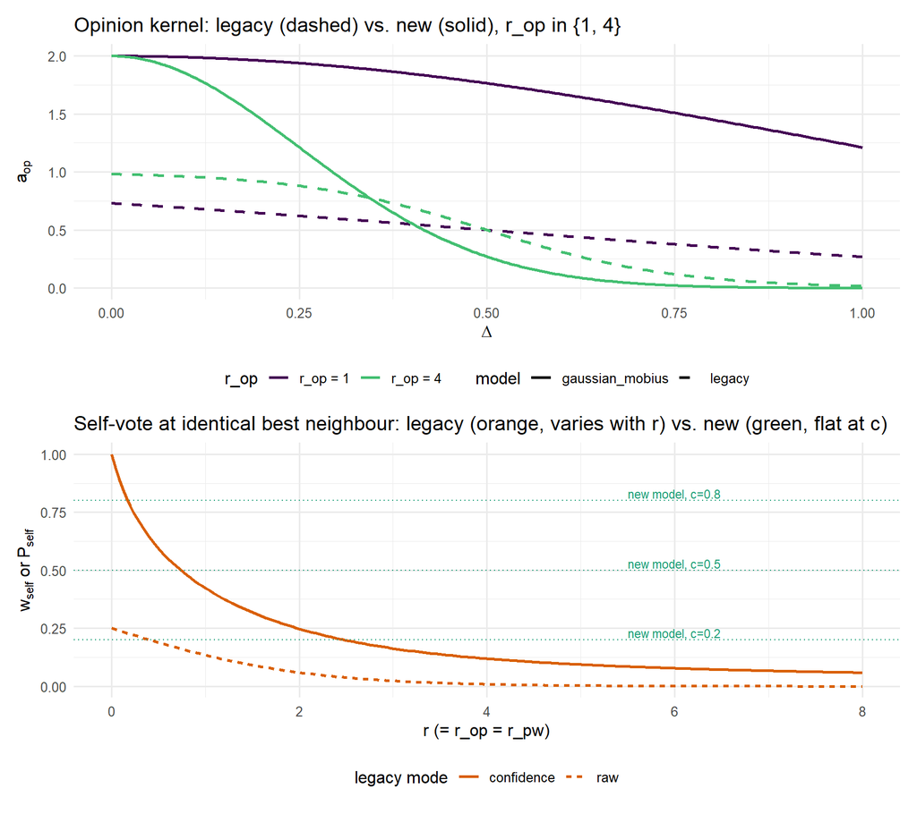

```r
p_op_overlay <- ggplot() +
  geom_line(data = df_op_old |> filter(r_op %in% c(1, 4)),
            aes(delta, a_op, colour = r_op_label, linetype = "legacy"), linewidth = 1) +
  geom_line(data = df_op_new |> filter(r_op %in% c(1, 4)),
            aes(delta, a_op, colour = r_op_label, linetype = "gaussian_mobius"), linewidth = 1) +
  scale_colour_viridis_d(end = 0.7) +
  scale_linetype_manual(values = c(legacy = "dashed", gaussian_mobius = "solid")) +
  labs(title = "Opinion kernel: legacy (dashed) vs. new (solid), r_op in {1, 4}",
       x = expression(Delta), y = expression(a[op]), colour = "r_op", linetype = "model") +
  theme(legend.position = "bottom")

p_pself_vs_old <- ggplot() +
  geom_line(data = df_conf, aes(r, w_self, linetype = mode), colour = "#d95f02", linewidth = 1) +
  geom_hline(data = tibble(c = c(0.2, 0.5, 0.8)), aes(yintercept = c),
             colour = "#1b9e77", linetype = "dotted") +
  annotate("text", x = 6, y = c(0.2, 0.5, 0.8) + 0.03,
           label = paste0("new model, c=", c(0.2, 0.5, 0.8)), colour = "#1b9e77", size = 3) +
  labs(title = "Self-vote at identical best neighbour: legacy (orange, varies with r) vs. new (green, flat at c)",
       x = "r (= r_op = r_pw)", y = expression(w[self]~"or"~P[self]), linetype = "legacy mode") +
  theme(legend.position = "bottom")

p_op_overlay / p_pself_vs_old
```

# 8 Part VII – Overall Assessment

## 8.1 Summary comparison table

```r
tibble(
  Dimension = c("Opinion gating", "Power gating", "Self-vote mechanism",
                "Self-reliance tunability", "Ceiling behaviour", "Known edge cases",
                "Continuity with Reports 15-19", "Recommended for"),
  `Legacy (dual sigmoid)` = c(
    "Sigmoid, fixed midpoint at Delta=0.5, steepness varies with r_op",
    "Sigmoid of log power ratio (shared with new model)",
    "Two-sigmoid mirror of attractiveness, evaluated at j*'s raw values",
    "Entangled with r_op/r_pw; patched via self_weight_mode='confidence'",
    "Approaches but never reaches 0.5 (identical neighbour) at finite r",
    "None known -- self-weight always in [0,1] regardless of trust",
    "Exact replication of all published results",
    "Continuity work; studies where responsiveness and self-reliance are meant to be the same trait"
  ),
  `Gaussian/Mobius` = c(
    "Gaussian, r_op-dependent bandwidth (half-width shrinks as 1/r_op)",
    "Sigmoid of log power ratio (shared with legacy model)",
    "Single Mobius curve of m = A_ij*, with named anchors",
    "Fully decoupled via dedicated parameter c",
    "Exactly 1 (identical neighbour), invariant to r_op/r_pw",
    "m can exceed 2 under strong reward+punish trust -> P_self < 0 (III.6)",
    "New for Report 20; r_op is not magnitude-comparable to legacy (III.4)",
    "New work specifically about self-reliance as an independent axis; cleaner default going forward"
  )
) |>
  kable(escape = FALSE)
```

| Dimension | Legacy (dual sigmoid) | Gaussian/Mobius |
| --- | --- | --- |
| Opinion gating | Sigmoid, fixed midpoint at Delta=0.5, steepness varies with r_op | Gaussian, r_op-dependent bandwidth (half-width shrinks as 1/r_op) |
| Power gating | Sigmoid of log power ratio (shared with new model) | Sigmoid of log power ratio (shared with legacy model) |
| Self-vote mechanism | Two-sigmoid mirror of attractiveness, evaluated at j*’s raw values | Single Mobius curve of m = A_ij*, with named anchors |
| Self-reliance tunability | Entangled with r_op/r_pw; patched via self_weight_mode=‘confidence’ | Fully decoupled via dedicated parameter c |
| Ceiling behaviour | Approaches but never reaches 0.5 (identical neighbour) at finite r | Exactly 1 (identical neighbour), invariant to r_op/r_pw |
| Known edge cases | None known – self-weight always in [0,1] regardless of trust | m can exceed 2 under strong reward+punish trust -> P_self < 0 (III.6) |
| Continuity with Reports 15-19 | Exact replication of all published results | New for Report 20; r_op is not magnitude-comparable to legacy (III.4) |
| Recommended for | Continuity work; studies where responsiveness and self-reliance are meant to be the same trait | New work specifically about self-reliance as an independent axis; cleaner default going forward |

## 8.2 Recommendation

For a thesis chapter whose explicit interest is *how self-reliance shapes delegation independently of opinion/power responsiveness* – which is what Report 20’s design suggests – **`gaussian_mobius` is the better-justified default going forward**: it removes an ad hoc patch (`"confidence"` mode), gives the self-reliance parameter a literal, checkable meaning ($c = P_{\text{self}}$ at an identical neighbour, for *any* $r$), and its ceiling behaviour is exact rather than asymptotic. `legacy` remains valuable and should stay available (as it already is, via one argument) for (a) exact replication of Reports 15-19, and (b) any analysis that specifically wants responsiveness and self-confidence to be the same underlying quantity.

## 8.3 Weaknesses of the new implementation, and concrete fixes

1. **Out-of-domain $m$ under strong trust (III.6).** *Fix:* clamp before evaluating the curve, preserving the formula’s intent while removing the sign flip:

   ```r
   p_self_mobius(pmin(w[j_idx], 2), self_reliance_c)
   ```

   A one-line change in `Network.R`’s `gaussian_mobius` branch. As a diagnostic, it would be worth logging how often the clamp actually binds across Report 20’s grid (likely rare at $\gamma\le8$, $\lambda=0.5$, but worth quantifying rather than assuming).
2. **$r_{op}$ not comparable across models (III.4).** *Fix:* either (a) explicitly caveat any cross-model $r_{op}$ comparison in the thesis text (the honest, zero-code option), or (b) recalibrate the `gaussian_mobius` sweep so its half-attractiveness distance matches the legacy sweep’s fixed $\Delta=0.5$ reference by construction – i.e. choose $r_{op}$ values from $r_{op} = \sqrt{2\ln2}/\Delta^\star$ for a chosen target $\Delta^\star$, rather than reusing Report 19’s raw numbers verbatim.
3. **No sensitivity instrumentation yet for $c$ specifically.** Report 20’s grid does not currently sweep `self_reliance_c` at all (it is fixed at $0.5$ throughout, per its setup chunk). Given III.3 identifies this as the headline new capability, a supplementary sweep over $c$ (holding $r_{ingroup}$ and $r_{background}$ fixed) would make direct use of the model’s main advantage rather than leaving it implicit.